# Brandon Daniel

## Project 4

In the notebook below, we will try to understand crimes within baltimore. More specifically, we will try to understand who are the main culprits (teens, adults, or elderly) and when they are planning their attacks. Small changes were made to this notebook in order for the reader to be able to more clearly understand the questions being asked in the supplied question bank for this project.

```python
!pip install folium
!pip install ggplot
import folium
import requests
import pandas
import seaborn as sb
import datetime
import time
from ggplot import *
%matplotlib inline
pandas.options.mode.chained_assignment = None  # default='warn'
```

To begin, we will first take a look at the data that we will be working with.

```python
arrest_table = pandas.read_csv("http://www.hcbravo.org/IntroDataSci/misc/BPD_Arrests.csv")

arrest_table["race_new"] = arrest_table["race"]
arrest_table["sex_new"] = arrest_table["sex"]
arrest_table["race"] = arrest_table["race_new"]
arrest_table["sex"] = arrest_table["sex_new"]
arrest_table = arrest_table.drop('race_new', 1)
arrest_table = arrest_table.drop('sex_new', 1)

arrest_table = arrest_table[pandas.notnull(arrest_table["Location 1"])]

arrest_table["lat"], arrest_table["long"] = arrest_table["Location 1"].str.split(",").str
arrest_table["lat"] = arrest_table["lat"].str.replace("(", "").astype(float)
arrest_table["long"] = arrest_table["long"].str.replace(")", "").astype(float)

arrest_table.head()
```

|  | arrest | age | race | sex | arrestDate | arrestTime | arrestLocation | incidentOffense | incidentLocation | charge | chargeDescription | district | post | neighborhood | Location 1 | lat | long |
| --- | --- | --- | --- | --- | --- | --- | --- | --- | --- | --- | --- | --- | --- | --- | --- | --- | --- |
| 1 | 11127013.0 | 37 | B | M | 01/01/2011 | 00:01:00 | 2000 Wilkens Ave | 79-Other | Wilkens Av & S Payson St | 1 1425 | Reckless Endangerment \|\| Hand Gun Violation | SOUTHERN | 934.0 | Carrollton Ridge | (39.2814026274, -76.6483635135) | 39.281403 | -76.648364 |
| 2 | 11126887.0 | 46 | B | M | 01/01/2011 | 00:01:00 | 2800 Mayfield Ave | Unknown Offense | NaN | NaN | Unknown Charge | NORTHEASTERN | 415.0 | Belair-Edison | (39.3227699160, -76.5735750473) | 39.322770 | -76.573575 |
| 3 | 11126873.0 | 50 | B | M | 01/01/2011 | 00:04:00 | 2100 Ashburton St | 79-Other | 2100 Ashburton St | 1 1106 | Reg Firearm:Illegal Possession \|\| Hgv | WESTERN | 735.0 | Panway/Braddish Avenue | (39.3117196723, -76.6623546313) | 39.311720 | -76.662355 |
| 4 | 11126968.0 | 33 | B | M | 01/01/2011 | 00:05:00 | 4000 Wilsby Ave | Unknown Offense | 1700 Aliceanna St | NaN | Unknown Charge | NORTHERN | 525.0 | Pen Lucy | (39.3382885254, -76.6045667070) | 39.338289 | -76.604567 |
| 5 | 11127041.0 | 41 | B | M | 01/01/2011 | 00:05:00 | 2900 Spellman Rd | 81-Recovered Property | 2900 Spelman Rd | 1 1425 | Reckless Endangerment \|\| Handgun Violation | SOUTHERN | 924.0 | Cherry Hill | (39.2449886230, -76.6273582432) | 39.244989 | -76.627358 |

## Begin Exploration

To unconver more information about the crime in this area, we will start by determining which disctrict has the most arrests.

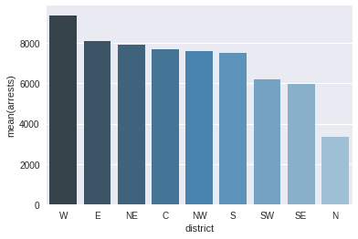

```python
# obtain occurrences in each district
densities_df = pandas.DataFrame()
densities = arrest_table['district'].value_counts()
densities_df['district'] = densities.index
densities_df['arrests'] = densities.values

# clean the districts so Plotting is clean
def prettyDistricts(district):
    return {
        'SOUTHERN': 'S',
        'NORTHERN': 'N',
        'EASTERN': 'E',
        'WESTERN': 'W',
        'NORTHEASTERN': 'NE',
        'NORTHWESTERN': 'NW',
        'SOUTHEASTERN': 'SE',
        'SOUTHWESTERN': 'SW',
        'CENTRAL': 'C'
    }[district]

densities_df['district'] = densities_df['district'].apply(prettyDistricts)

# plotting
ax = sb.barplot("district", y="arrests", data=densities_df, palette="Blues_d")
```

From the above bargraph of number of arrests per district. We can see that the Western district (W) seems to have the most activity, followed by the Eastern. We can take a closer look by examining where within the western district this activity has been occurring and what the sex of the criminal was.

```python
# grab all data from western and eastern district
western_df = pandas.DataFrame()
western_df = arrest_table[arrest_table['district'] == 'WESTERN']

# plot the locations on each of these
def maleFemaleColor(sex):
    if sex == 'M':
        return 'blue'
    else:
        return 'red'

# we take a random sample of 5% of the input data for a clean viz
map_osm = folium.Map(location=[39.30, -76.64], zoom_start=14)
random_sample = .05
for index, row in western_df.sample(frac=random_sample).iterrows():
    lat_long =  [row['lat'], row['long']]
    pop_up = folium.Popup(row['chargeDescription'], parse_html=True)
    folium.Marker(lat_long, popup=pop_up, icon=folium.Icon(color=maleFemaleColor(row['sex']))).add_to(map_osm)
map_osm
```

[interactive chart not shown]

### Observations

In the above visualization of a random sample with its sample size being 5% of the all Western district records, we can come to understand two very interesting observations. Firstly, the amount of arrests of `<font color=blue> men </font>` (in blue) seems to be significantly greater than the amount of `<font color=red> women </font>` (in red) arrested. Secondly, if we zoom in on the map, many of these arrests seem to be happening near the main roads such as West Baltimore Street, US-40, US-1, and US-1 US-40 Truck. For information about each crime, you can click on the marker to see that person's charge description.

We can then take this one step further. Now we will see the age of the offenders within this district and what time that they are being arrested.

```python
map_osm = folium.Map(location=[39.30, -76.64], zoom_start=14)
random_sample = .05
time_series = list()

#convert all string times to datetimes and add to df
for index, row in western_df.iterrows():
    # convert all times to python datetimes
    time_obj = datetime.datetime.strptime(row['arrestTime'], '%H:%M:%S').time()
    time_series.append(time_obj)

western_df['dateTime'] = time_series

def timeToColor(time_obj):
    """
    We will break up the times into 3 core regions. Before 6am crimes, between 6am and 8pm crimes,
    and after 8pm crimes. An arrest between a certain time range [a,b] will be assigned a
    specific color
    """
    if time_obj <= datetime.time(6,0):     # 1am to 6am
        return 'darkpurple'
    elif time_obj <= datetime.time(18,0):  # 6am to 8pm
        return 'orange'
    else:                                  # 8pm to midnight
        return 'darkpurple'

for index, row in western_df.sample(frac=random_sample).iterrows():
    lat_long =  [row['lat'], row['long']]
    pop_up = folium.Popup(str(row['age']), parse_html=True)
    folium.Marker(lat_long, popup=pop_up, icon=folium.Icon(color=timeToColor(row['dateTime']))).add_to(map_osm)
map_osm
```

[interactive chart not shown]

Based on the visualization above, we can observe that there are, marginally, more crimes within our sample of the western district are happening during the day than at night. If we click into the markers we can see the age of the criminals. We can plot the data in a different format in order to get a better sense of the distribution of ages within our simple random sample.

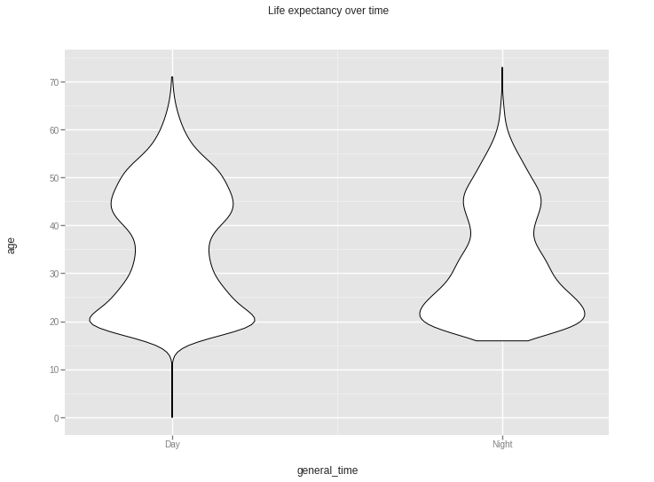

```python
# we will assign the color as its own series within our dataframe
colors = list()

for index, row in western_df.iterrows():
    colors.append(timeToColor(row['dateTime']))

western_df['time_color'] = colors

def nightDayTransform(time_color):
    """
    returned what each color represents
    """
    if time_color == 'darkpurple':
        return 'Night'
    else:
        return 'Day'

# create a label more understandable for plot
western_df['general_time'] = western_df['time_color'].apply (lambda x: nightDayTransform(x))

#plot time vs age
ggplot(aes(x='general_time', y='age'), data=western_df) +\
    geom_violin() +\
    labs(title="Life expectancy over time",
         x = "general_time",
         y = "age")
```

## Conclusion

When we look at all of the crimes within the western district, we come to notice that crimes during the day seem to be the most prevalent by individuals in their early twenties and mid forties. Crimes at night on the other hand seem to be most prevalent only by individuals in their early 20s. Most criminals in their mid 40s must be sleeping during the night and preform their crimes during the day.